# Project_Bank_Churn_Prediction

### Model -3

```python
# Tried  reducing the complexity
# By adding another Dropout
# Increased number of neurons in third and forth hidden layer.
```

```python
#initialize the model
model3 = Sequential()
model3.add(Dense(units=12, input_dim = X_train.shape[1]))  # First hidden layer
model3.add(Dense(units=32,activation='relu'))  # Second Hidden layer
model3.add(Dropout(0.2))  # Dropout added
model3.add(Dense(units=32,activation='relu'))  # Third Hidden layer
model3.add(Dropout(0.5))  # Dropout added
model3.add(Dense(units=128,activation='relu'))  # Forth Hidden layer

# Adding the output layer
# we have an output of 1 node, which is the the desired dimensions of our output (whether customer exit or not)
# We use the sigmoid because we have binary classification and looking for probability outputs.
model3.add(Dense(1,activation='sigmoid'))  # Output layer

#*****************************************************#
#  Model Compilation
#*****************************************************#
model3.summary()
optimizer = tf.keras.optimizers.Adam(0.001)  # optimizer function Adam is defined with learning rate = 0.01
model3.compile(optimizer=optimizer,loss='binary_crossentropy',metrics=[tf.keras.metrics.Recall(),'accuracy']) # metrics recall is used


#*****************************************************#
#  Training [Forward pass and Backpropagation]
#*****************************************************#
# fitting the model
# epochs is Number of epochs to train the model. Model1 is started with 10 epochs.
# batch_size is set to 150.
# training data set is split by 0.2 to use as validation dataset.
history3 = model3.fit(X_train,y_train,batch_size=150,epochs=20,validation_data=(X_val,y_val),)
```

```
Model: "sequential_2"
_________________________________________________________________
Layer (type)                 Output Shape              Param #
=================================================================
dense_9 (Dense)              (None, 12)                156
_________________________________________________________________
dense_10 (Dense)             (None, 32)                416
_________________________________________________________________
dropout_1 (Dropout)          (None, 32)                0
_________________________________________________________________
dense_11 (Dense)             (None, 32)                1056
_________________________________________________________________
dropout_2 (Dropout)          (None, 32)                0
_________________________________________________________________
dense_12 (Dense)             (None, 128)               4224
_________________________________________________________________
dense_13 (Dense)             (None, 1)                 129
=================================================================
Total params: 5,981
Trainable params: 5,981
Non-trainable params: 0
_________________________________________________________________
```

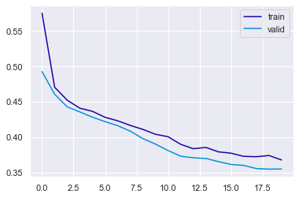

```python
# Capturing learning history per epoch
hist3  = pd.DataFrame(history3.history)
hist3['epoch'] = history3.epoch

# Plotting accuracy at different epochs
plt.plot(hist3['loss'])
plt.plot(hist3['val_loss'])
plt.legend(("train" , "valid") , loc = 0)
```

**Insights**

- Curves are smooth. meaning no much variance.
- Train and validation curve did Converge to some extent.
- no signs of over fit as validation and train values follow similar pattern and val_loss<loss and are nearer.

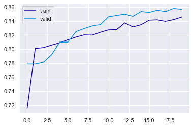

```python
# Capturing recall per epoch
hist3  = pd.DataFrame(history3.history)
hist3['epoch'] = history3.epoch

# Plotting recall at different epochs
plt.plot(hist3['accuracy'])
plt.plot(hist3['val_accuracy'])
plt.legend(("train" , "valid") , loc =0)
```

**Insights**

- validation curve has crossed train graph to exceed the train values.
- The model is not overfit.
- There is bit of variance in train graph.

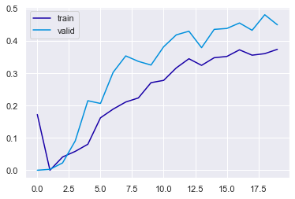

```python
# Capturing recall per epoch
hist3  = pd.DataFrame(history3.history)
hist3['epoch'] = history3.epoch

# Plotting recall at different epochs
plt.plot(hist3['recall_2'])
plt.plot(hist3['val_recall_2'])
plt.legend(("train" , "valid") , loc =0)
```

**Insights**

- The training and validation graphs look ideal. follow same pattern.
- Validation scores exceeded. This shows there is no over fit.
- validation graph is not smooth.there is variance.

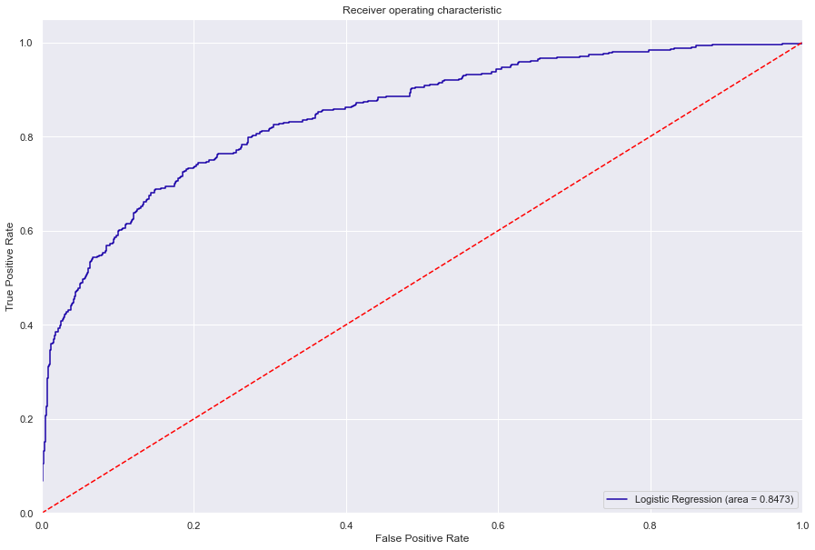

```python
#Built ROC-AUC Curve

logit_roc_auc3 = roc_auc_score(y_test, model3.predict(X_test))
fpr3, tpr3, thresholds3 = roc_curve(y_test, model3.predict(X_test))

#Plot graph for ROC-AUC
plt.figure(figsize=(15,10))
plt.plot(fpr3, tpr3, label='Logistic Regression (area = %0.4f)' % logit_roc_auc3)
plt.plot([0, 1], [0, 1],'r--')
plt.xlim([0.0, 1.0])
plt.ylim([0.0, 1.05])
plt.xlabel('False Positive Rate')
plt.ylabel('True Positive Rate')
plt.title('Receiver operating characteristic')
plt.legend(loc="lower right")
plt.show()
```

**Insights**

AUC looks normal as other models with no huge change.

```python
#Get optimal cutoff from ROC
optimal_proba_cutoff3 = sorted(list(zip(np.subtract(tpr3,fpr3), thresholds3)), key=lambda i: i[0], reverse=True)[0][1]
```

```python
optimal_proba_cutoff3
```

```
0.24840578
```

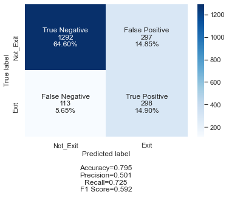

```python
# Convert prediction probabilites to predictions using optimal_proba_cutoff

## Confusion Matrix on unseen test set
import seaborn as sn
y_pred3 = model3.predict(X_test)
for i in range(len(y_test)):
    if y_pred3[i]> optimal_proba_cutoff3:
        y_pred3[i]=1
    else:
        y_pred3[i]=0



cm3=confusion_matrix(y_test, y_pred3)
labels = ['True Negative','False Positive','False Negative','True Positive']
categories = [ 'Not_Exit','Exit']

( accuracy3, precision3, recall3, f1_score3 ) = make_confusion_matrix(cm3,
                      group_names=labels,
                      categories=categories,
                      cmap='Blues')
```

**Insights**

```python
score_weighted3 = model3.evaluate(X_test, y_test)
```

### Metrics comparition dataframe

```python
# Add all metrics of model in one dataframe to facilitate comparition between models.

metrics_cols = ['model','epochs','learning_rate','recall','precision','accuracy','f1_score','ROC-AUC','Pred-Recall-AUC','prob_cut_off','model_desc']
model3_desc = '4 hidden layers,adding another Dropout, lr ramined same as model2, epoch decreased'
model_evaluation_metrics3 = pd.DataFrame(np.array([['model3',20, 0.001, recall3, precision3, accuracy3,f1_score3,logit_roc_auc3, 'NA',optimal_proba_cutoff3, model3_desc ]]), columns = metrics_cols)


# Increase column with for model_desc
def display_text_max_col_width(df, width):
    with pd.option_context('display.max_colwidth', width):
        pass

#append model3 metrics to summary df
metrics_camp = metrics_camp.append(model_evaluation_metrics3,ignore_index=True)

display_text_max_col_width(metrics_camp['model_desc'], 800)

# truncate the extra decimal values in numeric cols
for col in ['recall','precision','accuracy','f1_score','ROC-AUC','Pred-Recall-AUC','prob_cut_off']:
    metrics_camp[col] = metrics_camp[col].astype(str).str[:6]
metrics_camp
```

|  | model | epochs | learning_rate | recall | precision | accuracy | f1_score | ROC-AUC | Pred-Recall-AUC | prob_cut_off | model_desc |
| --- | --- | --- | --- | --- | --- | --- | --- | --- | --- | --- | --- |
| 0 | model1 | 10 | 0.01 | 0.7080 | 0.5521 | 0.822 | 0.6204 | 0.8492 | NA | 0.2253 | 2 hidden layers,no dropouts |
| 1 | model2 | 40 | 0.001 | 0.7007 | 0.5538 | 0.8225 | 0.6186 | 0.8445 | NA | 0.2415 | 3 hidden layers,one dropouts added, lr increas... |
| 2 | model3 | 20 | 0.001 | 0.7250 | 0.5008 | 0.795 | 0.5924 | 0.8472 | NA | 0.2484 | 4 hidden layers,adding another Dropout, lr ram... |

## Recall metrics tuning using threshold:

### Try Precision Recall curves on Model-2 and Model-3

- The given data set is imbalanced.
- If data is imbalanced and more importance is on True Positives, Precision Recall curves is more suitable

  ```
    So trying out this option.
  ```

```
Logistic: auc=0.684
```

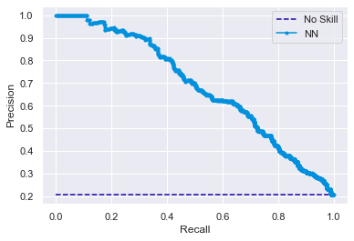

```python
#Precision-Recall curve for model-2

y_pred2 = model2.predict(X_test)  # find prediction probabilities
model2_precision, model2_recall, threshold_prc2 = precision_recall_curve(y_test, y_pred2)

model2_auc =  auc(model2_recall, model2_precision)
# summarize scores
print('Logistic: auc=%.3f' % ( model2_auc))
# plot the precision-recall curves
no_skill = len(y_test[y_test==1]) / len(y_test)
plt.plot([0, 1], [no_skill, no_skill], linestyle='--', label='No Skill')
plt.plot(model2_recall, model2_precision, marker='.', label='NN')
# axis labels
plt.xlabel('Recall')
plt.ylabel('Precision')
# show the legend
plt.legend()
# show the plot
plt.show()
```

**Insights**

- Precision recall graph AUC does not show very good number. Higher recall value is showing less precision. This is due to imbalanced dataset.

```python
# Calculate threshold from the graph such that model2_recall> 0.7 and model2_precision= 0.5

opt_threshould_prc2 = pd.DataFrame(list(zip(model2_recall,model2_precision, threshold_prc2)), columns = ['recall','precision', 'thresholds'])

opt_threshould_prc2_filter = opt_threshould_prc2.loc[opt_threshould_prc2['recall']>0.75  ]

opt_threshould_prc2_filter.tail()
```

|  | recall | precision | thresholds |
| --- | --- | --- | --- |
| 1339 | 0.751825 | 0.468182 | 0.206355 |
| 1340 | 0.751825 | 0.468892 | 0.206490 |
| 1341 | 0.751825 | 0.469605 | 0.206770 |
| 1342 | 0.751825 | 0.470320 | 0.207101 |
| 1343 | 0.751825 | 0.471037 | 0.207318 |

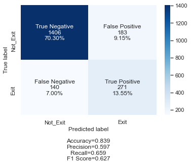

```python
# Convert prediction probabilites to predictions using optimal_proba_cutoff

# From the above table, threshold where recall is 0.700730 and precision is 0.524590 is choosen.

## Confusion Matrix on unseen test set

opt_threshould_prc2_cutoff = 0.260947
y_pred2 = model2.predict(X_test)
for i in range(len(y_test)):
    if y_pred2[i]> 0.260947:
        y_pred2[i]=1
    else:
        y_pred2[i]=0



cm2_prc=confusion_matrix(y_test, y_pred2)
labels = ['True Negative','False Positive','False Negative','True Positive']
categories = [ 'Not_Exit','Exit']

( accuracy2_prc, precision2_prc, recall2_prc, f1_score2_prc) = make_confusion_matrix(cm2_prc,
                      group_names=labels,
                      categories=categories,
                      cmap='Blues')
```

- The metric results are same as other models . not much difference.

```
Logistic: auc=0.676
```

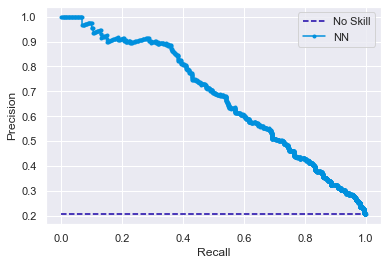

```python
#Precision-Recall curve for model-3

y_pred3 = model3.predict(X_test)  # find prediction probabilities
model3_precision, model3_recall, threshold_prc3 = precision_recall_curve(y_test, y_pred3)

model3_auc =  auc(model3_recall, model3_precision)
# summarize scores
print('Logistic: auc=%.3f' % ( model3_auc))
# plot the precision-recall curves
no_skill = len(y_test[y_test==1]) / len(y_test)
plt.plot([0, 1], [no_skill, no_skill], linestyle='--', label='No Skill')
plt.plot(model3_recall, model3_precision, marker='.', label='NN')
# axis labels
plt.xlabel('Recall')
plt.ylabel('Precision')
# show the legend
plt.legend()
# show the plot
plt.show()
```

```python
# Calculate threshold from the graph such that model2_recall> 0.75 and model2_precision= 0.5

opt_threshould_prc3 = pd.DataFrame(list(zip(model3_recall,model3_precision, threshold_prc3)), columns = ['recall','precision', 'thresholds'])

opt_threshould_prc3_filter = opt_threshould_prc3.loc[opt_threshould_prc3['recall']>0.75  ]


opt_threshould_prc3_filter.tail()
```

|  | recall | precision | thresholds |
| --- | --- | --- | --- |
| 1327 | 0.754258 | 0.460624 | 0.226916 |
| 1328 | 0.751825 | 0.459821 | 0.227182 |
| 1329 | 0.751825 | 0.460507 | 0.227439 |
| 1330 | 0.751825 | 0.461194 | 0.227626 |
| 1331 | 0.751825 | 0.461883 | 0.227647 |

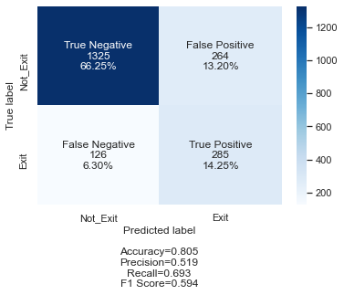

```python
# Convert prediction probabilites to predictions using optimal_proba_cutoff

# From the above table, threshold where recall is 0.746959 and precision is 0.480438 is choosen.

## Confusion Matrix on unseen test set
opt_threshould_prc3_cutoff = 0.262193

import seaborn as sn
y_pred3 = model3.predict(X_test)
for i in range(len(y_test)):
    if y_pred3[i]> opt_threshould_prc3_cutoff:
        y_pred3[i]=1
    else:
        y_pred3[i]=0



cm3_prc = confusion_matrix(y_test, y_pred3)
labels = ['True Negative','False Positive','False Negative','True Positive']
categories = [ 'Not_Exit','Exit']

( accuracy3_prc, precision3_prc, recall3_prc, f1_score3_prc) = make_confusion_matrix(cm3_prc,
                      group_names=labels,
                      categories=categories,
                      cmap='Blues')
```

- Scores are similar to other models. Not huge difference or improvement in metric scores.

### Metrics Summary of three models

```python
# Display  metrics summary of 3 models that are tuned with varioud hyper parameters and ROC-AUC Curve
metrics_camp
```

|  | model | epochs | learning_rate | recall | precision | accuracy | f1_score | ROC-AUC | Pred-Recall-AUC | prob_cut_off | model_desc |
| --- | --- | --- | --- | --- | --- | --- | --- | --- | --- | --- | --- |
| 0 | model1 | 10 | 0.01 | 0.7080 | 0.5521 | 0.822 | 0.6204 | 0.8492 | NA | 0.2253 | 2 hidden layers,no dropouts |
| 1 | model2 | 40 | 0.001 | 0.7007 | 0.5538 | 0.8225 | 0.6186 | 0.8445 | NA | 0.2415 | 3 hidden layers,one dropouts added, lr increas... |
| 2 | model3 | 20 | 0.001 | 0.7250 | 0.5008 | 0.795 | 0.5924 | 0.8472 | NA | 0.2484 | 4 hidden layers,adding another Dropout, lr ram... |

```python
# Creating summary dataframe for Precision-Recall curve outcomes.
metrics_prc_cols = ['model','recall','precision','Pred-Recall-AUC','prob_cut_off']
list_prc_metrics = [['model2',recall2_prc, precision2_prc, model2_auc , opt_threshould_prc2_cutoff],
                    ['model3',recall3_prc, precision3_prc, model3_auc , opt_threshould_prc3_cutoff]]

model_evaluation_metrics3_prc = pd.DataFrame(np.array(list_prc_metrics), columns = metrics_prc_cols)


display_text_max_col_width(metrics_camp['model_desc'], 800)
for col in ['recall','precision','Pred-Recall-AUC','prob_cut_off']:
    model_evaluation_metrics3_prc[col] = model_evaluation_metrics3_prc[col].astype(str).str[:6]

# Display  metrics summary of 3 models that are tuned with ROC-AUC Curve
model_evaluation_metrics3_prc
```

|  | model | recall | precision | Pred-Recall-AUC | prob_cut_off |
| --- | --- | --- | --- | --- | --- |
| 0 | model2 | 0.6593 | 0.5969 | 0.6844 | 0.2609 |
| 1 | model3 | 0.6934 | 0.5191 | 0.6764 | 0.2621 |

### Final Model Selection - Model-3 ROC-AUC Tuned

so Model3 can be declared as better model than model2.

Features of model-3 that helped for better rsults

- Model3 has 4 hidden layers
- 2 drop outs between layers [ decresed overfit and complexity of model].
- Less number of epochs [ less computation resources]
- learning rate is optimal to get smooth curves.

**Model3 Graphs**

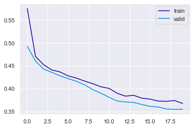

```python
# Capturing learning history per epoch
hist3  = pd.DataFrame(history3.history)
hist3['epoch'] = history3.epoch

# Plotting accuracy at different epochs
plt.plot(hist3['loss'])
plt.plot(hist3['val_loss'])
plt.legend(("train" , "valid") , loc = 0)
```

- both validation and train loss converge.
- Validation loss is less than train loss. so no overfit.
- graphs are smooth

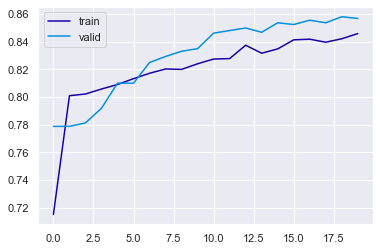

```python
# Capturing recall per epoch for model3
hist3  = pd.DataFrame(history3.history)
hist3['epoch'] = history3.epoch

# Plotting recall at different epochs
plt.plot(hist3['accuracy'])
plt.plot(hist3['val_accuracy'])
plt.legend(("train" , "valid") , loc =0)
```

- No overfit. Validation accuracy is more than trianing accuracy
- Accuracy score is also decent.

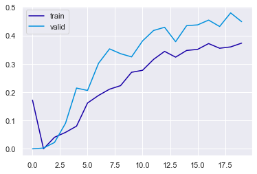

```python
# Capturing recall per epoch for model3
hist3  = pd.DataFrame(history3.history)
hist3['epoch'] = history3.epoch

# Plotting recall at different epochs
plt.plot(hist3['recall_2'])
plt.plot(hist3['val_recall_2'])
plt.legend(("train" , "valid") , loc =0)
```

**Insights**

- no overfit. Validation score is more than train score.
- Model still shows some variace. complexity can still be reduced.
  - This variance is not shown in accuracy.
  - This variance can be because of unbalanced data.

## Final Model Performance Evaluation

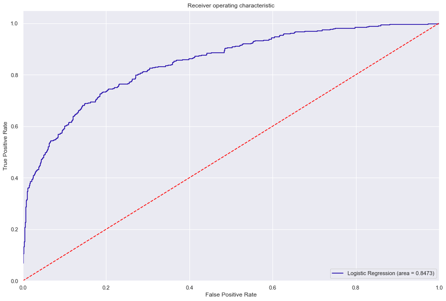

```python
# Display ROC-AUC curve for final model

#Built ROC-AUC Curve

logit_roc_auc3 = roc_auc_score(y_test, model3.predict(X_test))
fpr3, tpr3, thresholds3 = roc_curve(y_test, model3.predict(X_test))

#Plot graph for ROC-AUC
plt.figure(figsize=(15,10))
plt.plot(fpr3, tpr3, label='Logistic Regression (area = %0.4f)' % logit_roc_auc3)
plt.plot([0, 1], [0, 1],'r--')
plt.xlim([0.0, 1.0])
plt.ylim([0.0, 1.05])
plt.xlabel('False Positive Rate')
plt.ylabel('True Positive Rate')
plt.title('Receiver operating characteristic')
plt.legend(loc="lower right")
plt.show()
```

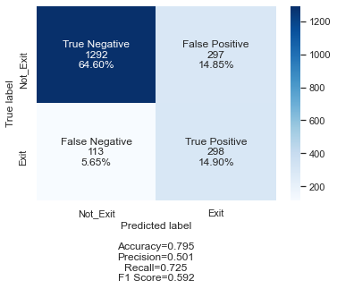

```python
# Display confusion matrics for final model

# Convert prediction probabilites to predictions using optimal_proba_cutoff

## Confusion Matrix on unseen test set
import seaborn as sn
y_pred3 = model3.predict(X_test)
for i in range(len(y_test)):
    if y_pred3[i]> optimal_proba_cutoff3:
        y_pred3[i]=1
    else:
        y_pred3[i]=0



cm3=confusion_matrix(y_test, y_pred3)
labels = ['True Negative','False Positive','False Negative','True Positive']
categories = [ 'Not_Exit','Exit']

( accuracy3, precision3, recall3, f1_score3 ) = make_confusion_matrix(cm3,
                      group_names=labels,
                      categories=categories,
                      cmap='Blues')
```

### Various metrics of final selected model( model-3 - ROC-AUC tuned )

Please find the analysis on different metrics :

- **Accuracy metric** : Accuracy formula is (TP+TF)/(TP+TF+FP+FN).  
  If the data is imbalanced. this is not good metirc to consider the performance of the model.  
  because even though there are huge FP or huge FN , the accuracy score will be more. This is not reliable incase of unbalanced dataset.
- **Recall** : Recall tells the overall capture of true +ve among actual +ve. so this is metric of interest in our problem because we want find the people who will exit. False Negatives are most costly than False Positive in this usecase.
- **Precision** is less and Recall is considerably more. This is also because of imbalance classes in dataset.
- **F1 Score:** F1 Score is primarity harmonic mean of precision and recall. so less value of F1 score is due to less value of precision. This can be used to compare model3 and model2 performances as
  - model2 has less recall and high precision
  - model3 has more recall and less precision IN such case , if for the usecase both precision and recall are important , we prefer the model which has high F1 score. But here recall is more important, so I prefer model3.

Performance:

- Recall score is better but it can be still improved because 113 False Negatives is still costly to the bank.
- Precision is low due to imbalanced dataset.
- As precision is low, f1 score is low.

Possible improvements than can be implemented.

- Data is imbalanced. so Resampling techniques can be applied to balanced the data and then train the model. But this is not suggestable as this approach would induce lot of junk data.
- Threshold can be tuned to get the optimal value
- Hyperparameter tuning can be used to reduce complexity and improve performance.

## Conclusion and key takeaways

**Conclusions**

- The dataset has highly imbalanced. actual +ve class count is very low. This is the reason for inverse behaviour of precision and recall.
- Data did not show proper correlation between the columns.
- Threshould can be tuned to increase recall further but that would increase False +ves.
- Dataset can contain other information like loans, marital status, number of kids etc that would help for better prediction.

**Key Takeaways**

- From EDA , below derivations appear from the data.
  - Account Balance,Number of Products,Age, CreditScore numbers show some affect on churn rate</B>
  - Customers with zero and ten tenure have exited less.</b>
    - This implies that people with low tenure may want to retain to check services for some more time.
    - people with more tenure want to retain as they got used to this bank.
  - Customers with mid credit score(600- 700) range exited more.
  - Also customer with high score also exited. This is shown by some unusual raise at the end.
    - Customers with high score might have got some better offers from other providers.
    - Customers with mid credit score might be not satisfied with the current bank services.
  - Germany has more customers who exited bank services than France and Spain.\
  - Female customers exited more.
  - Inactive members exited more.

**Suggestions**

- Business can concentrate on Female customers. can provide gender specific offers to attract Female customers.
- Germany geographical area can be concertrated to check why there is decrese in the numbers.
- Business can design some offers to make customers active. For example Business can give some offers on some prodcuts from their credit cards to encorage customers use the cards.
- Customers can plan some offers to retain customers with high credit score.
- Customers having or not having credit card did not impact churn rate. so credit cards are not having attractive services to retain the customers. Need some measures around this.
- There are very less customers with 3 or 4 products. Encourage customers to take more products.